# Introduction à R

Cours 3. IMPORTER ET NETTOYER DES DOCUMENTS

Yannick Rochat

1er décembre 2017

La cheatsheet pour l’importation et l’exportation de données.

https://github.com/rstudio/cheatsheets/raw/master/data-import.pdf

### Connaître l’emplacement du dossier de travail

`getwd` = *get working directory*

```r
getwd()
```

```
[1] "/Users/yrochat/Downloads/CoursProDocR/cours3"
```

### Modifier l’emplacement du dossier de travail

La touche de tabulation permet de naviguer plus efficacement dans les dossiers.

```r
setwd()
```

#### Sauver un texte

On crée un texte quelconque pour l’occasion. Le symbole `\n` est un retour à la ligne.

```r
dummy_text <- c("hello world\nhello world\nhello world\nhello world")
```

La fonction `cat` permet d’afficher du texte.

```r
cat(dummy_text)
```

```
hello world
hello world
hello world
hello world
```

La fonction `print` le permet aussi, mais le résultat est différent.

```r
print(dummy_text)
```

```
[1] "hello world\nhello world\nhello world\nhello world"
```

```r
write(dummy_text, file = "../data/dummy_text.txt")
```

- Les premiers `..` signifient que nous remontons d’un niveau.
- Puis nous entrons dans le dossier `data` et nous sauvons notre texte à cet endroit-là sous le nom `dummy_text.txt`.

#### Sauver un graphique

Lorsqu’on enregistre ou qu’on charge des données depuis ou vers R, celui-ci ouvre une connexion (souvent vu comme un «tunnel»).

L’exemple suivant sert à illustrer ceci.

```r
pdf("../outputs/dummy_output.pdf")
plot(1:10, rnorm(10))
dev.off()
```

- La fonction `pdf` ouvre un tunnel.
- Elle crée un fichier `dummy_output.pdf` sur l’ordinateur.
- Tous les résultats graphiques produits à partir de ce moment-là passent dans le tunnel.
- Ici l’exemple utilisé n’a pas d’importance. Il s’agit de représenter aléatoirement dix points côte à côte.
- La fonction `dev.off` ferme le tunnel. Ce n’est qu’à partir de ce moment-là que l’on peut accéder au fichier `pdf`.

#### Exercice 3.1

- Enregistrez cette phrase dans une variable.
- Sauvez-là au format `.txt`

#### Exercice 3.2

- Enregistrez le graphique suivant au format png sur votre ordinateur.

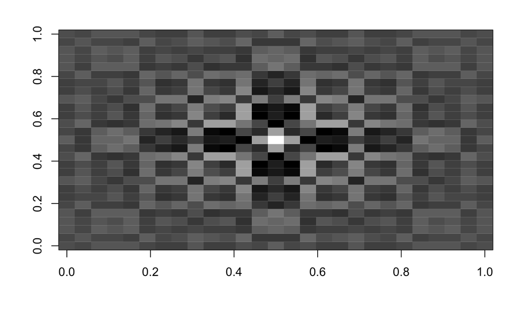

```r
x <- y <- seq(-4*pi, 4*pi, len = 27)
r <- sqrt(outer(x^2, y^2, "+"))
image(z = z <- cos(r^2)*exp(-r/6), col  = gray((0:32)/32))
```

### Le package `readr`

À partir de là, nous allons utiliser le package `readr` pour lire et écrire des informations textuelles.

Le code suivant vérifier si le package est installé sur votre machine et l’installe le cas échéant. Puis il le charge.

```r
if (!require(readr)) install.packages("readr")
library(readr)
```

- Les packages sont des ensembles de fonctions que l’on ajoute aux fonctions déjà disponibles.
- Les fonctions d’un package ont en général été regroupées autour d’une thématique commune.
- Dans notre cas: l’importation et l’exportation de données textuelles.

### csv (comma separated values)

Ne pas oublier les guillemets `"..."` autour du nom du fichier.

Pour découvrir pour quelle raison nous utilisons la fonction `read_csv2` et pas `read_csv`, consultez le fichier d’aide de ces fonctions. La réponse est dans le premier paragraphe.

```r
fifa <- read_csv2("../data/fifa.csv")
```

[output not shown]

Un aperçu.

```r
str(fifa)
```

```
Classes ‘tbl_df’, ‘tbl’ and 'data.frame':   36 obs. of  6 variables:
 $ journal: chr  "gamekult" "gamekult" "gamekult" "gamekult" ...
 $ note   : int  70 80 60 80 90 80 80 80 80 70 ...
 $ auteur : chr  "puyo" "puyo" "puyo" "puyo" ...
 $ url    : chr  "http://www.gamekult.com/jeux/test-fifa-17-SU3050706473t.html#ps4" "http://www.gamekult.com/jeux/test-fifa-16-SU3050463319t.html#ps4" "http://www.gamekult.com/jeux/test-fifa-15-SU3050259493t.html#ps4" "http://www.gamekult.com/jeux/test-fifa-14-SU3050130704t.html#ps3" ...
 $ annee  : int  2017 2016 2015 2014 2013 2012 2011 2010 2009 2008 ...
 $ texte  : chr  "Si vous avez un tant soit peu suivi l'actualité de FIFA 17 depuis son annonce, vous savez déjà qu'il ne s'agit pas d'un FIFA +1"| __truncated__ "Leurs trajectoires entrecroisées nous ont appris que rien n'est jamais acquis en matière de football virtuel. Et si FIFA aura t"| __trunc…
 - attr(*, "problems")=Classes ‘tbl_df’, ‘tbl’ and 'data.frame':    194 obs. of  4 variables:
  ..$ row     : int  1 1 1 1 1 1 1 1 1 1 ...
  ..$ col     : chr  "texte" "texte" "texte" "texte" ...
  ..$ expected: chr  "delimiter or quote" "delimiter or quote" "delimiter or quote" "delimiter or quote" ...
  ..$ actual  : chr  "R" "," "a" " " ...
 - attr(*, "spec")=List of 2
  ..$ cols   :List of 6
  .. ..$ journal: list()
  .. .. ..- attr(*, "class")= chr  "collector_character" "collector"
  .. ..$ note   : list()
  .. .. ..- attr(*, "class")= chr  "collector_integer" "collector"
  .. ..$ auteur : list()
  .. .. ..- attr(*, "class")= chr  "collector_character" "collector"
  .. ..$ url    : list()
  .. .. ..- attr(*, "class")= chr  "collector_character" "collector"
  .. ..$ annee  : list()
  .. .. ..- attr(*, "class")= chr  "collector_integer" "collector"
  .. ..$ texte  : list()
  .. .. ..- attr(*, "class")= chr  "collector_character" "collector"
  ..$ default: list()
  .. ..- attr(*, "class")= chr  "collector_guess" "collector"
  ..- attr(*, "class")= chr "col_spec"
```

Pour consulter l’objet importé - dans ce cas un tableau de données - vous pouvez vous rendre dans la fenêtre en haut à droite de RStudio puis dans l’onglet “Environment”. Vous trouverez le tableau sous “Data”. En double-cliquant dessus, il s’ouvrira dans cette fenêtre et vous pourrez vérifier que le tableau a bien été importé (en particulier dans le cas de “parsing failures”).

Il est également possible d’afficher le tableau assez élégament dans le notebook.

```r
fifa
```

| journal | note | auteur | url | annee | texte |
| --- | --- | --- | --- | --- | --- |
| gamekult | 70 | puyo | http://www.gamekult.com/jeux/test-fifa-17-SU3050706473t.html#ps4 | 2017 | Si vous avez un tant soit peu suivi l'actualité de FIFA 17 depuis son annonce, vous savez déjà qu'il ne s'agit pas d'un FIFA +1 comme il en paraît chaque année. Pour ce millésime 2016, la simu d'EA Sp… |
| gamekult | 80 | puyo | http://www.gamekult.com/jeux/test-fifa-16-SU3050463319t.html#ps4 | 2016 | Leurs trajectoires entrecroisées nous ont appris que rien n'est jamais acquis en matière de football virtuel. Et si FIFA aura toujours pour lui l'atout des licences, il suffirait d'une ou deux années … |
| gamekult | 60 | puyo | http://www.gamekult.com/jeux/test-fifa-15-SU3050259493t.html#ps4 | 2015 | Septembre, ce n'est pas seulement les impôts, la taxe d'habitation, les frais de rentrée scolaire et les transports bondés qui sentent l'urine. C'est aussi et heureusement le retour des simulations de… |
| gamekult | 80 | puyo | http://www.gamekult.com/jeux/test-fifa-14-SU3050130704t.html#ps3 | 2014 | On en aura avalé, du FIFA 14, entre les différents salons et les multiples présentations visant à présenter les versions sur la génération actuelle et celle qui suit. Le voilà enfin prêt à entrer dans… |
| gamekult | 90 | puyo | http://www.gamekult.com/jeux/test-fifa-13-SU3050020829t.html#ps3 | 2013 | A trop dominer la compétition, on court toujours le risque de se laisser aller à ronronner. Et pourtant, à l'image d'une équipe espagnole qui régale à chaque compétition internationale, les leaders du… |
| gamekult | 80 | puyo | http://www.gamekult.com/jeux/test-fifa-12-SU3010009326t.html#ps3 | 2012 | En champion dominant, le risque est grand de s'endormir sur sa couronne de lauriers, entouré de vestales et de raisin frais. Pourtant, EA Sports promettait une révolution pour FIFA 12, histoire d'enfo… |
| gamekult | 80 | puyo | http://www.gamekult.com/jeux/test-fifa-11-SU3010007360t.html#ps3 | 2011 | Toujours en position de force sur le marché des simulations de football, FIFA est bien décidé à enfoncer définitivement le clou. Remonté comme une pendule, à l'affût de la moindre remarque de la commu… |
| gamekult | 80 | puyo | http://www.gamekult.com/jeux/test-fifa-10-SU3010006597t.html#ps3 | 2010 | C'est sans doute la première année depuis des lustres que FIFA se présente en position de leader incontesté pour donner le coup d'envoi de la nouvelle saison de football virtuel. Plus attendue que jam… |
| gamekult | 80 | puyo | http://www.gamekult.com/jeux/test-fifa-09-SU3010005396t.html#ps3 | 2009 | Il n'y a qu'à fureter dans les kiosques. Chaque automne, le duel FIFA / PES embrase les fans de football virtuel, avec plusieurs millions de ventes comme enjeu, rien de moins. Cette année encore, FIFA… |
| gamekult | 70 | puyo | http://www.gamekult.com/jeux/test-fifa-08-SU3010004009t.html#ps3 | 2008 | La stratégie de FIFA se révèle aujourd'hui payante. Il nous aura fallu subir l'outrage d'un FIFA 06 360 calamiteux et d'une version de transition l'année dernière, c'est vrai. Mais pour avoir abordé l… |

[output cut: 26 more lines]

Pour sauver un fichier au format csv, il faut utiliser la fonction `write_csv`

```r
write_csv(fifa, "../outputs/fifa.csv")
```

#### xls (Microsoft Excel/libreOffice/Google Spreadsheets)

- On préfère en général sauver les fichiers au format csv car ils sont ainsi beaucoup plus légers et ne transportent pas l’encodage parfois lourd d’un fichier xls.
- Néanmoins, ce n’est pas toujours possible d’y échapper. Les données de l’OFS par exemple sont souvent fournies au format xls.

`readxl` est un package qui permet d’importer (et d’exporter) des fichiers au format xls.

```r
if (!require(readxl)) install.packages("readxl")
library(readxl)
```

Prenons un fichier au hasard de l’OFS : “Comportement de la population en matière de transport, chiffres clés - agglomération de Lausanne (définition 2000)”

https://www.bfs.admin.ch/bfs/fr/home/statistiques/catalogues-banques-donnees/tableaux.assetdetail.2082350.html

Il est présent dans le dossier `data`.

La fonction `read_excel` est ce qu’il nous faut.

```r
ouch <- read_excel("../data/su-f-11.04.03-MZ-2015-A2_5586_Def2000.xls")
ouch
```

| Comportement de la population en matière de transport, chiffres clés 2015 - agglomération de Lausanne (définition 2000) | X__1 | X__2 | X__3 | X__4 | X__5 | X__6 | X__7 | X__8 | X__9 | X__10 | X__11 | X__12 | X__13 | X__14 | X__15 | X__16 | X__17 | X__18 | X__19 | X__20 | X__21 | X__22 | X__23 | X__24 | X__25 | X__26 | X__27 | X__28 | X__29 | … |
| --- | --- | --- | --- | --- | --- | --- | --- | --- | --- | --- | --- | --- | --- | --- | --- | --- | --- | --- | --- | --- | --- | --- | --- | --- | --- | --- | --- | --- | --- | --- |
| Disponibilité d'une voiture, possession de permis et d'abonnement, taux de mobilité, distance journalière, durée moyenne des déplacements, nombre d'étapes, de déplacements et de boucles | NA | NA | NA | NA | NA | NA | NA | NA | NA | NA | NA | NA | NA | NA | NA | NA | NA | NA | NA | NA | NA | NA | NA | NA | NA | NA | NA | NA | NA | … |
| NA | Outils de transport | NA | NA | NA | NA | NA | Taux de mobilité | NA | Distance journalière moyenne | NA | NA | NA | NA | NA | NA | NA | NA | NA | NA | NA | Durée moyenne des déplacements (sans les temps d'attente et de correspondance) | NA | NA | NA | NA | NA | NA | NA | Durée moyenne des déplacements (avec les temps d'attente et de correspondance) | … |
| NA | Disponibilité d'une voiture | NA | Possession du permis de conduire | NA | Possession d'abonnements des TP | NA | Personnes mobiles le jour de référence (en déplacement) | NA | Total | NA | Mobilité douce | NA | Transport individuel motorisé | NA | Transports publics | NA | Travail | NA | Loisirs | NA | Total | NA | Mobilité douce | NA | Transport individuel motorisé | NA | Transports publics | NA | Total | … |
| NA | [%] | +/- | [%] | +/- | [%] | +/- | [%] | +/- | [km] | +/- | [km] | +/- | [km] | +/- | [km] | +/- | [km] | +/- | [km] | +/- | [min.] | +/- | [min.] | +/- | [min.] | +/- | [min.] | +/- | [min.] | … |
| Total | 71.4115 | 2.1529 | 79.8513 | 1.1019 | 54.3067 | 2.1106 | 90.4037 | 1.17046 | 35.5673 | 2.32061 | 2.36454 | 0.171007 | 23.6062 | 1.9457 | 8.99945 | 1.38181 | 8.00385 | 0.992232 | 15.2014 | 1.5775 | 83.4761 | 2.95896 | 33.8018 | 1.95036 | 36.286 | 2.12484 | 12.1186 | 1.20763 | 91.7101 | … |
| Sexe | NA | NA | NA | NA | NA | NA | NA | NA | NA | NA | NA | NA | NA | NA | NA | NA | NA | NA | NA | NA | NA | NA | NA | NA | NA | NA | NA | NA | NA | … |
| Hommes | 74.3044 | 2.97627 | 86.008 | 1.36905 | 50.2544 | 3.12199 | 92.0342 | 1.58443 | 42.5661 | 3.87164 | 2.61895 | 0.316168 | 29.3717 | 3.43756 | 9.81285 | 2.07237 | 10.2624 | 1.75221 | 17.8717 | 2.71804 | 90.6838 | 4.85461 | 34.3687 | 3.19645 | 42.6214 | 3.65036 | 12.0045 | 1.80518 | 98.796 | … |
| Femmes | 68.3852 | 3.10034 | 74.2657 | 1.67276 | 58.0207 | 2.8467 | 88.9186 | 1.69932 | 29.1924 | 2.67773 | 2.13282 | 0.159665 | 18.3547 | 2.0123 | 8.25857 | 1.85004 | 5.94668 | 1.03606 | 12.7691 | 1.74159 | 76.9109 | 3.52492 | 33.2854 | 2.35132 | 30.5155 | 2.32926 | 12.2225 | 1.62281 | 85.256 | … |
| Âge | NA | NA | NA | NA | NA | NA | NA | NA | NA | NA | NA | NA | NA | NA | NA | NA | NA | NA | NA | NA | NA | NA | NA | NA | NA | NA | NA | NA | NA | … |
| 6-17 ans | NA | NA | NA | NA | 94.668 | 5.2259 | 93.521 | 2.53343 | 21.0427 | 3.57939 | 2.31624 | 0.271526 | 13.9333 | 3.49492 | 4.46693 | 1.1545 | 0.0995569 | 0.0950689 | 14.8308 | 3.59038 | 71.6638 | 6.24265 | 35.8242 | 4.60626 | 22.0013 | 3.76109 | 11.7911 | 2.22828 | 80.5613 | … |

[output cut: 29 more lines]

Toutes les entrées sont considérées comme des chaînes de caractères.

```r
str(ouch)
```

```
Classes ‘tbl_df’, ‘tbl’ and 'data.frame':   39 obs. of  55 variables:
 $ Comportement de la population en matière de transport, chiffres clés 2015 - agglomération de Lausanne (définition 2000): chr  "Disponibilité d'une voiture, possession de permis et d'abonnement, taux de mobilité, distance journalière, durée moyenne des dé"| __truncated__ NA NA NA ...
 $ X__1                                                                                                                   : chr  NA "Outils de transport" "Disponibilité d'une voiture" "[%]" ...
 $ X__2                                                                                                                   : chr  NA NA NA "+/-" ...
 $ X__3                                                                                                                   : chr  NA NA "Possession du permis de conduire" "[%]" ...
 $ X__4                                                                                                                   : chr  NA NA NA "+/-" ...
 $ X__5                                                                                                                   : chr  NA NA "Possession d'abonnements des TP" "[%]" ...
 $ X__6                                                                                                                   : chr  NA NA NA "+/-" ...
 $ X__7                                                                                                                   : chr  NA "Taux de mobilité" "Personnes mobiles le jour de référence (en déplacement)" "[%]" ...
 $ X__8                                                                                                                   : chr  NA NA NA "+/-" ...
 $ X__9                                                                                                                   : chr  NA "Distance journalière moyenne" "Total" "[km]" ...
 $ X__10                                                                                                                  : chr  NA NA NA "+/-" ...
 $ X__11                                                                                                                  : chr  NA NA "Mobilité douce" "[km]" ...
 $ X__12                                                                                                                  : chr  NA NA NA "+/-" ...
 $ X__13                                                                                                                  : chr  NA NA "Transport individuel motorisé" "[km]" ...
```

[output cut: 41 more lines]

Le résultat n’est pas directement exploitable, et ce sera souvent le cas au moment de récupérer des fichiers publics, souvent bizarrement structurés.

Important : les fonctions utilisées traditionnellement pour importer des tableaux (par ex. `read.table`) importent par défaut les variables au format “factor”, un concept spécifique à R et aux langages prévus pour faire des statistiques. Ce format s’emploie principalement lorsqu’une variable est catégorielle ordinale, c’est-à-dire que les valeurs qu’elle peut prendre sont parmi un ensemble de “mots” (catégorielle) et qu’on peut les classer (ordinale), par exemple l’ensemble : “très mauvais”, “mauvais”, “bon”, “très bon”.

Pour obtenir ce résultat, il faut utiliser (quand elle est disponible) l’option `stringsAsFactors = TRUE` qui est généralement vraie («`TRUE`») par défaut.

Le même genre de technique peut être utilisé pour lire des fichiers aux formats suivants.

| but | fonction |
| --- | --- |
| pur texte | `read_file`, `read_lines` |
| png | `readPNG` |
| spss | package `haven` |
| json | package `jsonlite` |
| xml | package `xml2` |

#### Exercice 3.3

- Importez un fichier xls présent sur votre ordinateur ou en ligne (par exemple sur le site de l’OFS).
- Une fois importé, qu’est-ce qui pose problème avec le résultat ? Que devrait-on corriger ? Comment le corriger ?